# Capítulo 1: Primeiros passos

**Nome do aluno(a)**: Lucas Lima Rodrigues  
**Matrícula**: 1142345353  
**Telefone**: (68) 99999-9999  
**E-mail**: lucaslrodri@cursopythonufac.github.br

## A interface do Jupyter

Para entendermos o conceito de células, vamos simplesmente copiar e colar sempre alternando entre o modo texto (Markdown) e o modo código (Python).

```python
# Está célula está em Python.
# Iremos escrever nossa primeira célula
print("Olá mundo")
```

```
Olá mundo
```

Esta célula está em Markdown e apresenta uma função quadrática: $$y(t)=t^2+2t+3$$

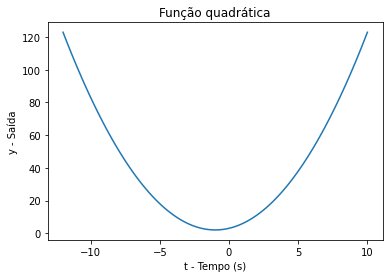

```python
# Esta célula está em Python e está plotando a equação acima

import matplotlib.pyplot as plt
import numpy as np
t = np.linspace(-12, 10, num=100)
y = t**2+2*t+3
plt.plot(t, y)
plt.xlabel('t - Tempo (s)')
plt.ylabel('y - Saída')
plt.title('Função quadrática')
plt.show()
```

Vamos resetar o Kernel e executar as células de código (Python) na seguinte ordem:

> Usamos `Ctrl+Enter` para executar uma célula e os botões $\uparrow$ e $\downarrow$ para mover entre as células.

```python
# Célula de código 1
# Função: Atribua o valor 0 à variável 'x'
x=0
```

```python
# Célula de código 2
# Incremente esta variável em 1
x=x+1
```

```python
# Célula de código 3
# Mostre o valor de 'x'
x
```

```
1
```

## Atividade 2: Introdução Markdown

**Nome**: Lucas Lima Rodrigues

**Cor favorita**: Azul

**Capítulo**: Primeiro capítulo

**Data**: *11 de setembro de 2020*

Como escrever um código em Markdown:

```
ling = "python"

if ling != "python":
    print("Essa linguagem não serve para nada")
else:
    print("Melhor linguagem.")
```

Vamos aprender como fazer uma citação:

> O ceu é azul e a grama é verde, porque a grama tem clorofila.  
> Olá mundo

Como faz uma lista:

**Listas ordenadas**:

Meus pokemons favoritos:

1. Dragonite
2. Lucario
3. Pikachu
4. Charmander

**Lista não ordenada**

Coisas que eu tenho que comprar no supermercado:

- Ovo
- Lasanha
- Carne
- Arroz
- Feijão
- Coquinha gelada

Fazer um bolo:

- Ingredientes:
  - Ovo
  - Farinha de trigo
  - Leite
  - Fermento
- Modo de preparo:
  1. Bata no liquidificador o leite com o ovo
  2. Jogue a farinha de trigo na mistura
  3. Bote para assar

## Atividade 3: Primeiros passos com o Python

### Parte 1: Comentários

Nesta parte iremos aprender como fazer comentários:

```python
# Isto é um comentário e não pode ser executado
# Comentários servem para você explicar o seu código e adiciona informações adicionais
# Usando o '#' eu crio um comentário com uma única linha


'''
Capítulo 1: Primeiros passos
----------------
Data: 11 de setembro de 2020
E-mail: blablabla@blablabla.com
Telefone: (68) 111111-11111
Estado: Acre
'''

#Precisamos adicionar qualquer código para o comentário não gerar uma string multilinha
print('')
```

### Parte 2: Operadores

Alguns operadores são os mesmos da matemática. Você trabalha como se estivesse fazendo uma operação numa calculadora:

```python
2+2
```

```
4
```

```python
2+3+6
```

```
11
```

```python
23/7
```

```
3.2857142857142856
```

```python
3*9
```

```
27
```

```python
7-4
```

```
3
```

Outros operadores:

- Exponenciação "**":

```python
2**3
```

```
8
```

- Parte inteira "//":

```python
8//7
```

```
1
```

```python
23//7
```

```
3
```

```python
50//3
```

```
16
```

- Resto "%"

```python
23%7
```

```
2
```

```python
40%4
```

```
0
```

```python
43%4
```

```
3
```

Além disso, podemos utilizar parênteses que nem na matemática:

```python
(5-1)*((7+1)/(3-1))
```

```
16.0
```

Agora vamos praticar alguns exemplos:

- $\frac{8}{2}\times (2+2)$

```python
8/2*(2+2)
```

```
16.0
```

- $(2+3)\times 3^3$

```python
(2+3)*3**3
```

```
135
```

- $7+7\div 7+7\times 7-7$

```python
7+7/7+7*7-7
```

```
50.0
```

- Raiz quadrada  
  $x^{0,5}=\sqrt{x}$

```python
# x**(0.5)=raiz de x
```

Raiz de 4:

```python
4**0.5
```

```
2.0
```

Vamos executar o seguinte código:

```
5+
```

```python
5+
```

```
  File "<ipython-input-25-7fd34a819fa2>", line 1
    5+
      ^
SyntaxError: invalid syntax
```

### Parte 3: Tipos de dados

Os principais tipos de dados do Python são:

- Inteiros:

  > -2,-1,0,1,2,111111,-11111
- Decimais (Ponto flutante):

  > 1.25, 5.43, 9.9, 10.1
- Strings (Palavras):

  > 'a', "abacaxi", "Hello!", 'curso de python'

Execute a string `python` no modo código:

```python
'python'
```

[output not shown]

Operações com string:

- Concatenação "+"

```python
"curso "+"de "+"Python"
```

[output not shown]

Concatenem as seguintes strings para formar uma frase:

- `O`
- `céu`
- `é`
- `Azul`
- O operador de de repetição, "*", pode ser dado da seguinte forma:

```python
5 * 'abacaxi '
```

[output not shown]

Utilizando as seguintes strings:

- `O`
- `céu`
- `é`
- `Azul`

```python
'O '+'céu '+'é '+3*'azul '
```

[output not shown]